#### 1.1 2020 Presidential Election

Due to the COVID-19 pandemic, we expect the early voter turnout rates could be higher than the past and show some interesting patterns. To investigate this, we display the result of 2020 early votes in Texas; in-person, by-mail, and total.

During this election cycle, Early Voting in person and mail in voting were popular methods of voting for Americans especially for Democrats. As Texas has been a Red state for presidential elections for 40 years, we hypothesized that high early voting percentages (either in person or mail) could be an indication that the county could potentially swing to picking a Democrat.

## Historic Voting Patterns

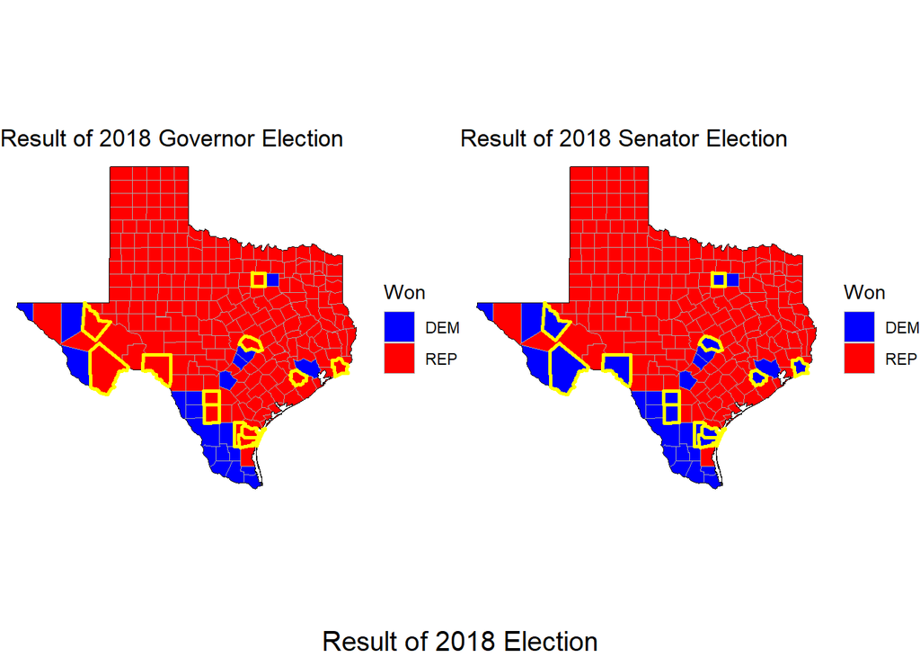

We hoped to find patterns in Texas’s early vote to forecast the 2020 presidential election. To first understand the voting habits of Texans, we observed the 2018 Governor and Senate election. We were surprised to discover 12 counties that had voted Republican for the Governor election, but Democrat for the Senator Election. The governor and senate election took place on the same day, and it was odd that a voter would select a candidate from the opposite party for the specific election. We designated these 12 counties as “swing” counties as voters were open to change and searched for patterns within these 12 counties.

## Result of 2020 Early Vote (In Person)

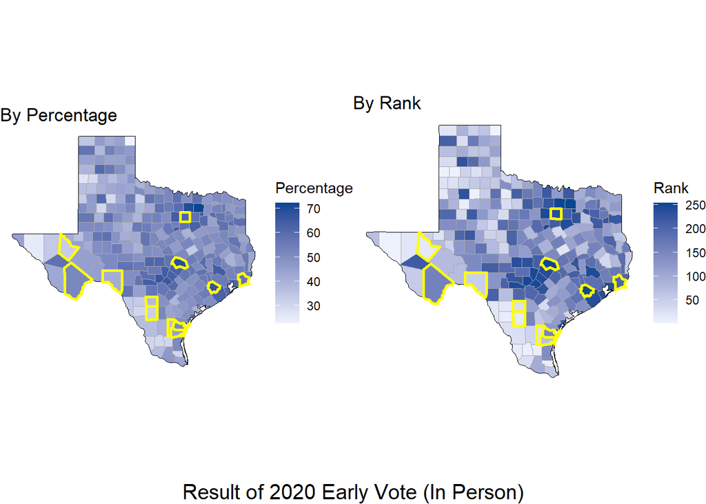

```
## # A tibble: 12 x 3
##    County     region value
##    <chr>       <dbl> <dbl>
##  1 Williamson  48491  69.2
##  2 Fort Bend   48157  67.6
##  3 Tarrant     48439  62.2
##  4 Jefferson   48245  57.1
##  5 Brewster    48043  52.1
##  6 Nueces      48355  51.9
##  7 Kleberg     48273  44.6
##  8 Val Verde   48465  41.7
##  9 Frio        48163  38.0
## 10 Jim Wells   48249  36.0
## 11 Reeves      48389  32.9
## 12 La Salle    48283  32
```

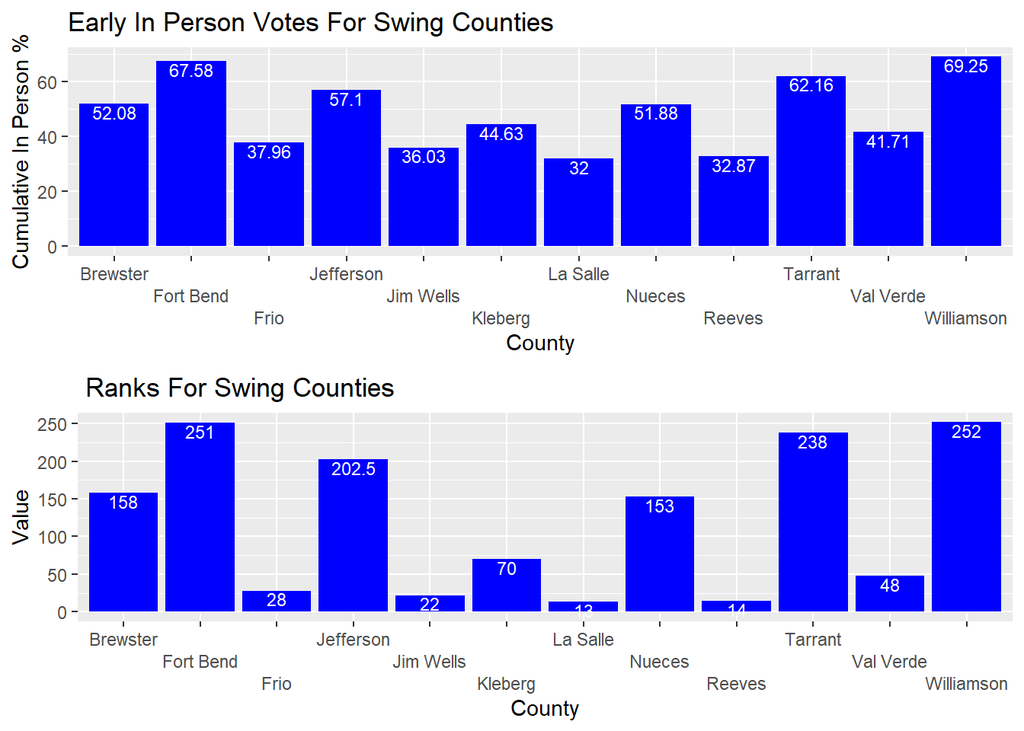

The Cumulative In Person Data showed us that only 6 of the 12 counties had an Early In person Voting percentage higher than 50% with 4 of the counties having a In person voting percentage approximately higher than 60%. If we held the assumption that most of the voters voting early are democrats, we can expect the democratic candidate to win the 4 counties with a cumulative in person voting percent close to 60%. However, it is difficult to create a generalized assumption of pattern from just this data.

## Result of 2020 Early Vote (By Mail)

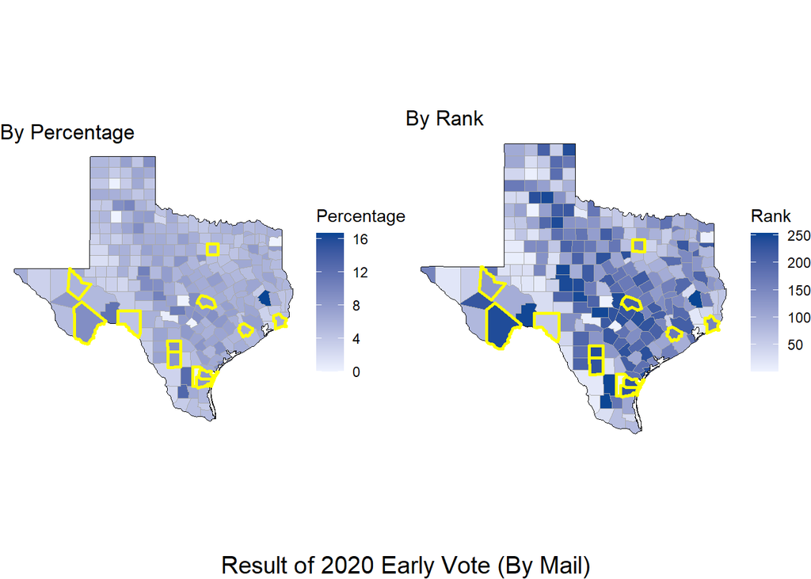

```
## # A tibble: 12 x 3
##    County     region value
##    <chr>       <dbl> <dbl>
##  1 Brewster    48043  9.2
##  2 Frio        48163  9.07
##  3 La Salle    48283  8.27
##  4 Nueces      48355  8.25
##  5 Kleberg     48273  8.14
##  6 Williamson  48491  7.41
##  7 Fort Bend   48157  6.33
##  8 Jefferson   48245  6.13
##  9 Tarrant     48439  5.87
## 10 Reeves      48389  5.63
## 11 Val Verde   48465  4.06
## 12 Jim Wells   48249  0.02
```

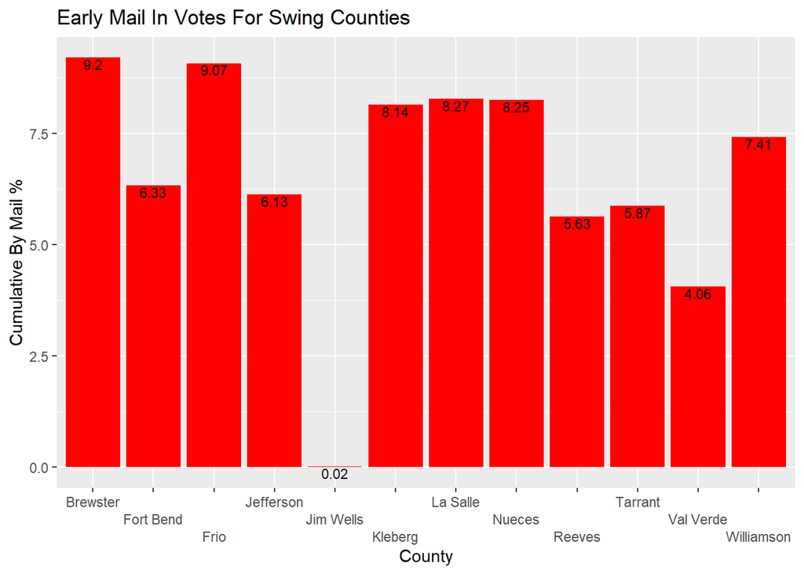

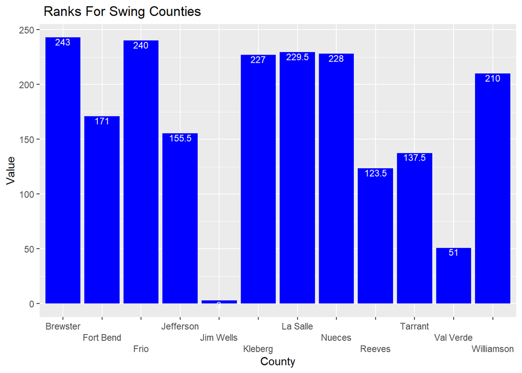

The Cumulative Mail in Data presented us with the percentage of the population which chose to vote early with mail in voting. In out 12 “swing” counties, our analysis showed a low percentage of the population in these counties chose to take advantage of the mail in voting with the highest being 9% and the lowest being 0.02%.

## Result of 2020 Early Vote (Total)

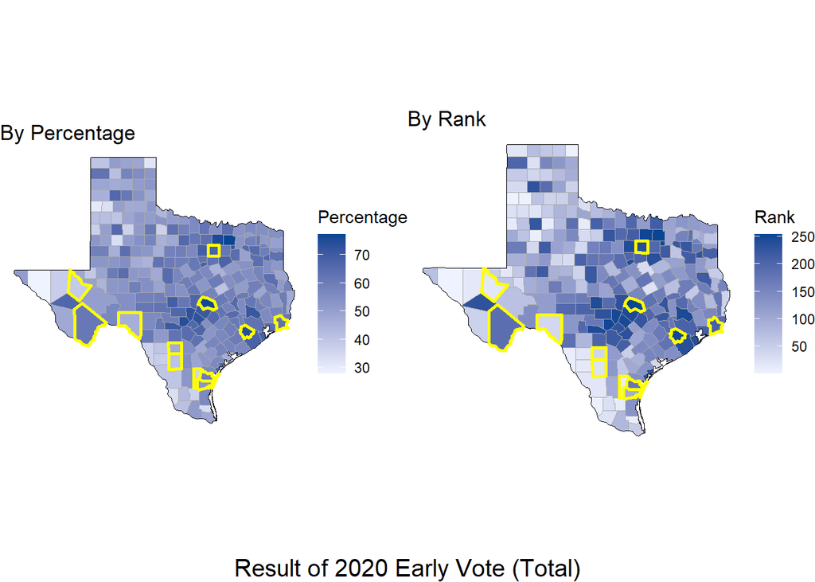

```
## # A tibble: 12 x 3
##    County     region value
##    <chr>       <dbl> <dbl>
##  1 Williamson  48491  76.7
##  2 Fort Bend   48157  73.9
##  3 Tarrant     48439  68.0
##  4 Jefferson   48245  63.2
##  5 Brewster    48043  61.3
##  6 Nueces      48355  60.1
##  7 Kleberg     48273  52.8
##  8 Frio        48163  47.0
##  9 Val Verde   48465  45.8
## 10 La Salle    48283  40.3
## 11 Reeves      48389  38.5
## 12 Jim Wells   48249  36.0
```

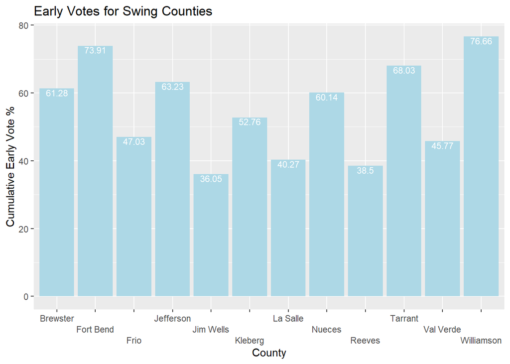

The total Cumulative Early Vote Percentage Data and Graph gives us a clearer understanding of how Texas counties voted in the election. From the 12 “swing” counties, we find that 7 counties had a Early Vote Percentage higher than 50%. If we hold our assumption that Democrats are more likely to vote early and knowing that citizens within these 12 counties have been known to vote for democratic candidates before, it is possible to assume these counties would choose a democratic presidential candidate as a majority of their citizen had voted early. However, it is difficult to conclude a generalized voting pattern just based on these results. Especially since the Republican candidate won a majority of the counties in the 2020 Election turning the state red once more. To create a more generalized pattern of forecasting the election results, variables such as Income, Age, and demographic distribution should be observed.

## 2020 Cumulative Early Vote Percentage By Day

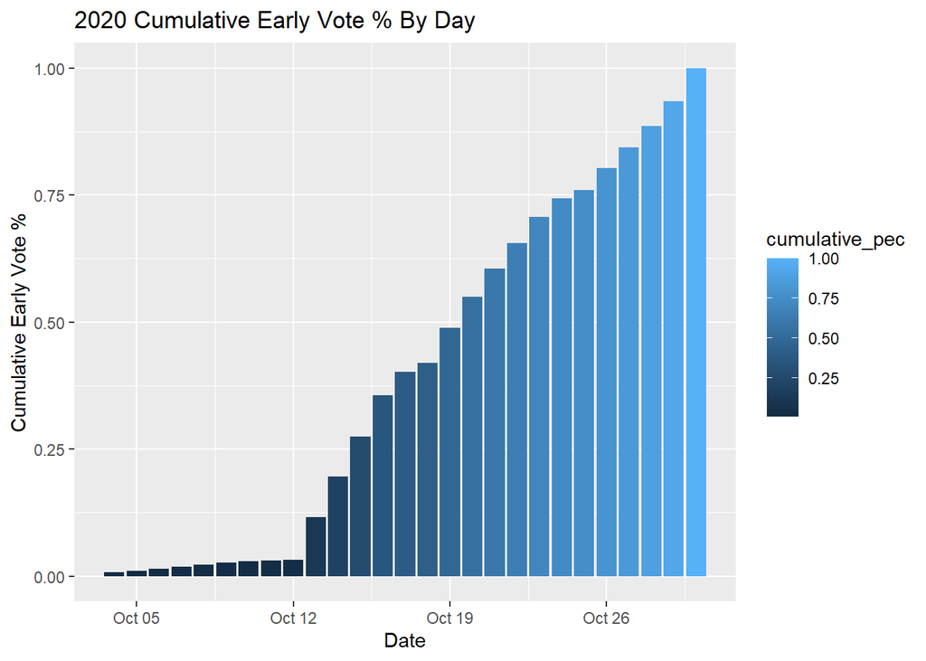

When looking at the state’s cumulative early votes by day, we see an incredible surge in early voting on October 13th. A quick google search on this date and October 12th shows no major political events on this date.

## Cumulative percentage of Early Votes by Day

*It can take up to 3 min to be fully loaded.*

[interactive chart not shown]

There was a ton of media coverage regarding the early vote in Texas. We decided that it would be helpful to show the cumulative percentage of non-suspended voters that voted each day with an R-Shiny application.

## Final Thoughts

As the 2020 election has ended, we can see that Tarrant, Williamson, and Fort Bend did end up picking the democratic candidate. Solidifying the assumption that we cannot just use early voting to try and forecase the state’s election results. Although polls and the news cycles made it seem like democrats were more likely to vote early, with the Coronavirus many republican voters most likely also took advantage of the early voting methods.